# Risk Factor Analysis

## Outcome Variable

**Outcome Variable:** stunted

## Predictor Variables

**Intervention Variable:** tr

**Adjustment Set:**

unadjusted

## Stratifying Variables

The analysis was stratified on these variable(s):

- nrooms
- agecat
- studyid
- country

## Data Summary

| nrooms | agecat | studyid | country | tr | stunted | n_cell | n |
| --- | --- | --- | --- | --- | --- | --- | --- |
| 2 | 6 months | ki1000125-AgaKhanUniv | PAKISTAN | Control | 0 | 44 | 96 |
| 2 | 6 months | ki1000125-AgaKhanUniv | PAKISTAN | Control | 1 | 19 | 96 |
| 2 | 6 months | ki1000125-AgaKhanUniv | PAKISTAN | Maternal | 0 | 27 | 96 |
| 2 | 6 months | ki1000125-AgaKhanUniv | PAKISTAN | Maternal | 1 | 6 | 96 |
| 4+ | 6 months | ki1000125-AgaKhanUniv | PAKISTAN | Control | 0 | 13 | 29 |
| 4+ | 6 months | ki1000125-AgaKhanUniv | PAKISTAN | Control | 1 | 5 | 29 |
| 4+ | 6 months | ki1000125-AgaKhanUniv | PAKISTAN | Maternal | 0 | 10 | 29 |
| 4+ | 6 months | ki1000125-AgaKhanUniv | PAKISTAN | Maternal | 1 | 1 | 29 |
| 1 | 6 months | ki1000125-AgaKhanUniv | PAKISTAN | Control | 0 | 51 | 108 |
| 1 | 6 months | ki1000125-AgaKhanUniv | PAKISTAN | Control | 1 | 28 | 108 |
| 1 | 6 months | ki1000125-AgaKhanUniv | PAKISTAN | Maternal | 0 | 19 | 108 |
| 1 | 6 months | ki1000125-AgaKhanUniv | PAKISTAN | Maternal | 1 | 10 | 108 |
| 3 | 6 months | ki1000125-AgaKhanUniv | PAKISTAN | Control | 0 | 16 | 34 |
| 3 | 6 months | ki1000125-AgaKhanUniv | PAKISTAN | Control | 1 | 3 | 34 |
| 3 | 6 months | ki1000125-AgaKhanUniv | PAKISTAN | Maternal | 0 | 12 | 34 |
| 3 | 6 months | ki1000125-AgaKhanUniv | PAKISTAN | Maternal | 1 | 3 | 34 |
| 1 | 24 months | ki1000125-AgaKhanUniv | PAKISTAN | Control | 1 | 1 | 1 |
| 1 | Birth | ki1000125-AgaKhanUniv | PAKISTAN | Control | 0 | 2 | 3 |
| 1 | Birth | ki1000125-AgaKhanUniv | PAKISTAN | Maternal | 0 | 1 | 3 |
| 4+ | Birth | ki1000125-AgaKhanUniv | PAKISTAN | Maternal | 0 | 1 | 1 |
| 4+ | 6 months | ki1000304-VITAMIN-A | INDIA | Control | 0 | 57 | 165 |
| 4+ | 6 months | ki1000304-VITAMIN-A | INDIA | Control | 1 | 21 | 165 |
| 4+ | 6 months | ki1000304-VITAMIN-A | INDIA | VitA | 0 | 71 | 165 |
| 4+ | 6 months | ki1000304-VITAMIN-A | INDIA | VitA | 1 | 16 | 165 |
| 1 | 6 months | ki1000304-VITAMIN-A | INDIA | Control | 0 | 487 | 1523 |
| 1 | 6 months | ki1000304-VITAMIN-A | INDIA | Control | 1 | 283 | 1523 |
| 1 | 6 months | ki1000304-VITAMIN-A | INDIA | VitA | 0 | 494 | 1523 |
| 1 | 6 months | ki1000304-VITAMIN-A | INDIA | VitA | 1 | 259 | 1523 |
| 2 | 6 months | ki1000304-VITAMIN-A | INDIA | Control | 0 | 196 | 614 |
| 2 | 6 months | ki1000304-VITAMIN-A | INDIA | Control | 1 | 111 | 614 |

[output cut: 250 more lines]

The following strata were considered:

- nrooms: 1, agecat: 24 months, studyid: iLiNS_DYADM_LNS, country: MALAWI
- nrooms: 1, agecat: 24 months, studyid: ki1000125-AgaKhanUniv, country: PAKISTAN
- nrooms: 1, agecat: 24 months, studyid: ki1000304-ZnMort, country: INDIA
- nrooms: 1, agecat: 24 months, studyid: ki1017093b-PROVIDE, country: BANGLADESH
- nrooms: 1, agecat: 24 months, studyid: ki1148112-iLiNS-DOSE, country: MALAWI
- nrooms: 1, agecat: 24 months, studyid: ki1148112-iLiNS-DYAD-M, country: MALAWI
- nrooms: 1, agecat: 24 months, studyid: kiGH5241-JiVitA-3, country: BANGLADESH
- nrooms: 1, agecat: 24 months, studyid: kiGH5241-JiVitA-4, country: BANGLADESH
- nrooms: 1, agecat: 6 months, studyid: iLiNS_DYADM_LNS, country: MALAWI
- nrooms: 1, agecat: 6 months, studyid: ki1000125-AgaKhanUniv, country: PAKISTAN
- nrooms: 1, agecat: 6 months, studyid: ki1000304-VITAMIN-A, country: INDIA
- nrooms: 1, agecat: 6 months, studyid: ki1000304-ZnMort, country: INDIA
- nrooms: 1, agecat: 6 months, studyid: ki1017093b-PROVIDE, country: BANGLADESH
- nrooms: 1, agecat: 6 months, studyid: ki1148112-iLiNS-DOSE, country: MALAWI
- nrooms: 1, agecat: 6 months, studyid: ki1148112-iLiNS-DYAD-M, country: MALAWI
- nrooms: 1, agecat: 6 months, studyid: kiGH5241-JiVitA-3, country: BANGLADESH
- nrooms: 1, agecat: 6 months, studyid: kiGH5241-JiVitA-4, country: BANGLADESH
- nrooms: 1, agecat: Birth, studyid: ki1000125-AgaKhanUniv, country: PAKISTAN
- nrooms: 1, agecat: Birth, studyid: kiGH5241-JiVitA-3, country: BANGLADESH
- nrooms: 1, agecat: Birth, studyid: kiGH5241-JiVitA-4, country: BANGLADESH
- nrooms: 2, agecat: 24 months, studyid: iLiNS_DYADM_LNS, country: MALAWI
- nrooms: 2, agecat: 24 months, studyid: ki1000304-ZnMort, country: INDIA
- nrooms: 2, agecat: 24 months, studyid: ki1148112-iLiNS-DOSE, country: MALAWI
- nrooms: 2, agecat: 24 months, studyid: ki1148112-iLiNS-DYAD-M, country: MALAWI
- nrooms: 2, agecat: 24 months, studyid: kiGH5241-JiVitA-3, country: BANGLADESH
- nrooms: 2, agecat: 24 months, studyid: kiGH5241-JiVitA-4, country: BANGLADESH
- nrooms: 2, agecat: 6 months, studyid: iLiNS_DYADM_LNS, country: MALAWI
- nrooms: 2, agecat: 6 months, studyid: ki1000125-AgaKhanUniv, country: PAKISTAN
- nrooms: 2, agecat: 6 months, studyid: ki1000304-VITAMIN-A, country: INDIA
- nrooms: 2, agecat: 6 months, studyid: ki1000304-ZnMort, country: INDIA
- nrooms: 2, agecat: 6 months, studyid: ki1017093b-PROVIDE, country: BANGLADESH
- nrooms: 2, agecat: 6 months, studyid: ki1148112-iLiNS-DOSE, country: MALAWI
- nrooms: 2, agecat: 6 months, studyid: ki1148112-iLiNS-DYAD-M, country: MALAWI
- nrooms: 2, agecat: 6 months, studyid: kiGH5241-JiVitA-3, country: BANGLADESH
- nrooms: 2, agecat: 6 months, studyid: kiGH5241-JiVitA-4, country: BANGLADESH
- nrooms: 2, agecat: Birth, studyid: kiGH5241-JiVitA-3, country: BANGLADESH
- nrooms: 2, agecat: Birth, studyid: kiGH5241-JiVitA-4, country: BANGLADESH
- nrooms: 3, agecat: 24 months, studyid: iLiNS_DYADM_LNS, country: MALAWI
- nrooms: 3, agecat: 24 months, studyid: ki1000304-ZnMort, country: INDIA
- nrooms: 3, agecat: 24 months, studyid: ki1148112-iLiNS-DOSE, country: MALAWI
- nrooms: 3, agecat: 24 months, studyid: ki1148112-iLiNS-DYAD-M, country: MALAWI
- nrooms: 3, agecat: 24 months, studyid: kiGH5241-JiVitA-3, country: BANGLADESH
- nrooms: 3, agecat: 24 months, studyid: kiGH5241-JiVitA-4, country: BANGLADESH
- nrooms: 3, agecat: 6 months, studyid: iLiNS_DYADM_LNS, country: MALAWI
- nrooms: 3, agecat: 6 months, studyid: ki1000125-AgaKhanUniv, country: PAKISTAN
- nrooms: 3, agecat: 6 months, studyid: ki1000304-VITAMIN-A, country: INDIA
- nrooms: 3, agecat: 6 months, studyid: ki1000304-ZnMort, country: INDIA
- nrooms: 3, agecat: 6 months, studyid: ki1017093b-PROVIDE, country: BANGLADESH
- nrooms: 3, agecat: 6 months, studyid: ki1148112-iLiNS-DOSE, country: MALAWI
- nrooms: 3, agecat: 6 months, studyid: ki1148112-iLiNS-DYAD-M, country: MALAWI
- nrooms: 3, agecat: 6 months, studyid: kiGH5241-JiVitA-3, country: BANGLADESH
- nrooms: 3, agecat: 6 months, studyid: kiGH5241-JiVitA-4, country: BANGLADESH
- nrooms: 3, agecat: Birth, studyid: kiGH5241-JiVitA-3, country: BANGLADESH
- nrooms: 3, agecat: Birth, studyid: kiGH5241-JiVitA-4, country: BANGLADESH
- nrooms: 4+, agecat: 24 months, studyid: iLiNS_DYADM_LNS, country: MALAWI
- nrooms: 4+, agecat: 24 months, studyid: ki1000304-ZnMort, country: INDIA
- nrooms: 4+, agecat: 24 months, studyid: ki1148112-iLiNS-DOSE, country: MALAWI
- nrooms: 4+, agecat: 24 months, studyid: ki1148112-iLiNS-DYAD-M, country: MALAWI
- nrooms: 4+, agecat: 24 months, studyid: kiGH5241-JiVitA-3, country: BANGLADESH
- nrooms: 4+, agecat: 24 months, studyid: kiGH5241-JiVitA-4, country: BANGLADESH
- nrooms: 4+, agecat: 6 months, studyid: iLiNS_DYADM_LNS, country: MALAWI
- nrooms: 4+, agecat: 6 months, studyid: ki1000125-AgaKhanUniv, country: PAKISTAN
- nrooms: 4+, agecat: 6 months, studyid: ki1000304-VITAMIN-A, country: INDIA
- nrooms: 4+, agecat: 6 months, studyid: ki1000304-ZnMort, country: INDIA
- nrooms: 4+, agecat: 6 months, studyid: ki1017093b-PROVIDE, country: BANGLADESH
- nrooms: 4+, agecat: 6 months, studyid: ki1148112-iLiNS-DOSE, country: MALAWI
- nrooms: 4+, agecat: 6 months, studyid: ki1148112-iLiNS-DYAD-M, country: MALAWI
- nrooms: 4+, agecat: 6 months, studyid: kiGH5241-JiVitA-3, country: BANGLADESH
- nrooms: 4+, agecat: 6 months, studyid: kiGH5241-JiVitA-4, country: BANGLADESH
- nrooms: 4+, agecat: Birth, studyid: ki1000125-AgaKhanUniv, country: PAKISTAN
- nrooms: 4+, agecat: Birth, studyid: kiGH5241-JiVitA-3, country: BANGLADESH
- nrooms: 4+, agecat: Birth, studyid: kiGH5241-JiVitA-4, country: BANGLADESH

### Dropped Strata

Some strata were dropped due to rare outcomes:

- nrooms: 4+, agecat: 6 months, studyid: ki1000125-AgaKhanUniv, country: PAKISTAN
- nrooms: 3, agecat: 6 months, studyid: ki1000125-AgaKhanUniv, country: PAKISTAN
- nrooms: 1, agecat: 24 months, studyid: ki1000125-AgaKhanUniv, country: PAKISTAN
- nrooms: 1, agecat: Birth, studyid: ki1000125-AgaKhanUniv, country: PAKISTAN
- nrooms: 4+, agecat: Birth, studyid: ki1000125-AgaKhanUniv, country: PAKISTAN
- nrooms: 3, agecat: 6 months, studyid: ki1000304-ZnMort, country: INDIA
- nrooms: 4+, agecat: 24 months, studyid: ki1000304-ZnMort, country: INDIA
- nrooms: 3, agecat: 24 months, studyid: ki1000304-ZnMort, country: INDIA
- nrooms: 4+, agecat: 6 months, studyid: ki1000304-ZnMort, country: INDIA
- nrooms: 2, agecat: 6 months, studyid: ki1017093b-PROVIDE, country: BANGLADESH
- nrooms: 1, agecat: 6 months, studyid: ki1017093b-PROVIDE, country: BANGLADESH
- nrooms: 3, agecat: 6 months, studyid: ki1017093b-PROVIDE, country: BANGLADESH
- nrooms: 1, agecat: 24 months, studyid: ki1017093b-PROVIDE, country: BANGLADESH
- nrooms: 4+, agecat: 6 months, studyid: ki1017093b-PROVIDE, country: BANGLADESH
- nrooms: 3, agecat: 6 months, studyid: ki1148112-iLiNS-DYAD-M, country: MALAWI
- nrooms: 2, agecat: 24 months, studyid: ki1148112-iLiNS-DYAD-M, country: MALAWI
- nrooms: 4+, agecat: 6 months, studyid: ki1148112-iLiNS-DYAD-M, country: MALAWI
- nrooms: 4+, agecat: 24 months, studyid: ki1148112-iLiNS-DYAD-M, country: MALAWI
- nrooms: 1, agecat: 24 months, studyid: ki1148112-iLiNS-DYAD-M, country: MALAWI
- nrooms: 3, agecat: 24 months, studyid: ki1148112-iLiNS-DYAD-M, country: MALAWI
- nrooms: 3, agecat: 24 months, studyid: kiGH5241-JiVitA-3, country: BANGLADESH
- nrooms: 2, agecat: 24 months, studyid: kiGH5241-JiVitA-3, country: BANGLADESH
- nrooms: 4+, agecat: 24 months, studyid: kiGH5241-JiVitA-3, country: BANGLADESH
- nrooms: 3, agecat: Birth, studyid: kiGH5241-JiVitA-4, country: BANGLADESH
- nrooms: 4+, agecat: Birth, studyid: kiGH5241-JiVitA-4, country: BANGLADESH
- nrooms: 4+, agecat: 24 months, studyid: kiGH5241-JiVitA-4, country: BANGLADESH
- nrooms: 3, agecat: 6 months, studyid: iLiNS_DYADM_LNS, country: MALAWI
- nrooms: 2, agecat: 24 months, studyid: iLiNS_DYADM_LNS, country: MALAWI
- nrooms: 4+, agecat: 6 months, studyid: iLiNS_DYADM_LNS, country: MALAWI
- nrooms: 4+, agecat: 24 months, studyid: iLiNS_DYADM_LNS, country: MALAWI
- nrooms: 1, agecat: 24 months, studyid: iLiNS_DYADM_LNS, country: MALAWI
- nrooms: 3, agecat: 24 months, studyid: iLiNS_DYADM_LNS, country: MALAWI

## Methods Detail

We’re interested in the causal parameters $E[Y_a]$ for all values of $a \in \mathcal{A}$. These parameters represent the mean outcome if, possibly contrary to fact, we intervened to set all units to have $A=a$. Under the randomization and positivity assumptions, these are identified by the statistical parameters $\psi_a=E_W[E_{Y|A,W}(Y|A=a,W)]$. In addition, we’re interested in the mean of $Y$, $E[Y]$ under no intervention (the observed mean). We will estimate these parameters by using SuperLearner to fit the relevant likelihood factors – $E_{Y|A,W}(Y|A=a,W)$ and $p(A=a|W)$, and then updating our likelihood fit using a joint TMLE.

For unadjusted analyses ($W=\{\}$), initial likelihoods were estimated using Lrnr_glm to estimate the simple $E(Y|A)$ and Lrnr_mean to estimate $p(A)$. For adjusted analyses, a small library containing Lrnr_glmnet, Lrnr_xgboost, and Lrnr_mean was used.

Having estimated these parameters, we will then use the delta method to estimate relative risks and attributable risks relative to a prespecified baseline level of $A$.

# Results Detail

## Results Plots

[figure not shown]

[figure not shown]

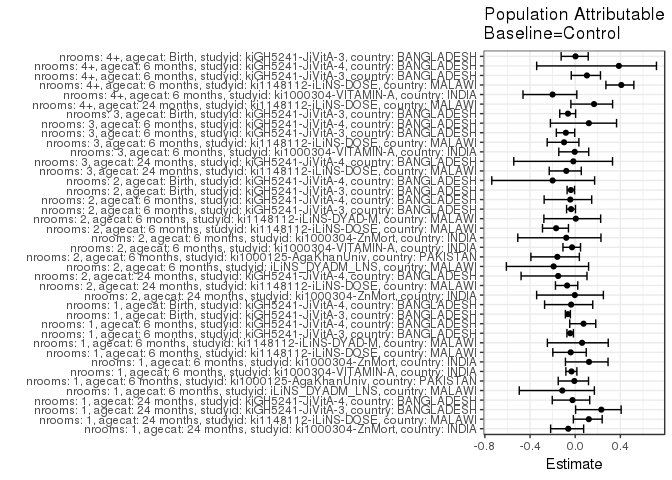

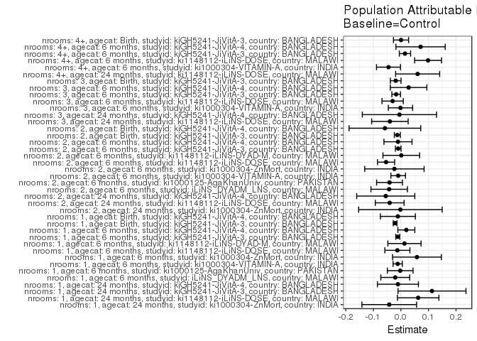

## Results Table

### Parameter: TSM

| nrooms | agecat | studyid | country | intervention_level | baseline_level | estimate | ci_lower | ci_upper |
| --- | --- | --- | --- | --- | --- | --- | --- | --- |
| 1 | Birth | kiGH5241-JiVitA-3 | BANGLADESH | Control | NA | 0.3457790 | 0.3391706 | 0.3523873 |
| 1 | Birth | kiGH5241-JiVitA-3 | BANGLADESH | Maternal | NA | 0.3045904 | 0.2981201 | 0.3110607 |
| 1 | Birth | kiGH5241-JiVitA-4 | BANGLADESH | Control | NA | 0.3112583 | 0.2384417 | 0.3840748 |
| 1 | Birth | kiGH5241-JiVitA-4 | BANGLADESH | LNS | NA | 0.3385827 | 0.2404378 | 0.4367275 |
| 1 | Birth | kiGH5241-JiVitA-4 | BANGLADESH | Other | NA | 0.2719298 | 0.2096568 | 0.3342028 |
| 1 | 6 months | iLiNS_DYADM_LNS | MALAWI | Control | NA | 0.2000000 | 0.1321388 | 0.2678612 |
| 1 | 6 months | iLiNS_DYADM_LNS | MALAWI | LNS | NA | 0.1515152 | 0.0994242 | 0.2036061 |
| 1 | 6 months | ki1000125-AgaKhanUniv | PAKISTAN | Control | NA | 0.3544304 | 0.2769137 | 0.4319470 |
| 1 | 6 months | ki1000125-AgaKhanUniv | PAKISTAN | Maternal | NA | 0.3448276 | 0.2981593 | 0.3914959 |
| 1 | 6 months | ki1000304-VITAMIN-A | INDIA | Control | NA | 0.3675325 | 0.3503097 | 0.3847552 |
| 1 | 6 months | ki1000304-VITAMIN-A | INDIA | VitA | NA | 0.3439575 | 0.3271769 | 0.3607381 |
| 1 | 6 months | ki1000304-ZnMort | INDIA | Control | NA | 0.4186047 | 0.2700048 | 0.5672045 |
| 1 | 6 months | ki1000304-ZnMort | INDIA | Zinc | NA | 0.5909091 | 0.3838598 | 0.7979584 |
| 1 | 6 months | ki1148112-iLiNS-DOSE | MALAWI | Control | NA | 0.3333333 | 0.3133347 | 0.3533319 |
| 1 | 6 months | ki1148112-iLiNS-DOSE | MALAWI | LNS | NA | 0.3181818 | 0.2727078 | 0.3636559 |
| 1 | 6 months | ki1148112-iLiNS-DYAD-M | MALAWI | Control | NA | 0.2000000 | 0.1510773 | 0.2489227 |
| 1 | 6 months | ki1148112-iLiNS-DYAD-M | MALAWI | Maternal | NA | 0.2222222 | 0.1620583 | 0.2823861 |
| 1 | 6 months | kiGH5241-JiVitA-3 | BANGLADESH | Control | NA | 0.2711683 | 0.2636125 | 0.2787240 |
| 1 | 6 months | kiGH5241-JiVitA-3 | BANGLADESH | Maternal | NA | 0.2488844 | 0.2418059 | 0.2559629 |
| 1 | 6 months | kiGH5241-JiVitA-4 | BANGLADESH | Control | NA | 0.2476698 | 0.2121693 | 0.2831703 |
| 1 | 6 months | kiGH5241-JiVitA-4 | BANGLADESH | LNS | NA | 0.2652284 | 0.2317751 | 0.2986817 |
| 1 | 6 months | kiGH5241-JiVitA-4 | BANGLADESH | Other | NA | 0.2801858 | 0.2507148 | 0.3096568 |
| 1 | 24 months | ki1000304-ZnMort | INDIA | Control | NA | 0.7297297 | 0.5855026 | 0.8739569 |
| 1 | 24 months | ki1000304-ZnMort | INDIA | Zinc | NA | 0.6296296 | 0.4460406 | 0.8132186 |
| 1 | 24 months | ki1148112-iLiNS-DOSE | MALAWI | Control | NA | 0.4583333 | 0.4245224 | 0.4921442 |
| 1 | 24 months | ki1148112-iLiNS-DOSE | MALAWI | LNS | NA | 0.5338983 | 0.4588389 | 0.6089577 |
| 1 | 24 months | kiGH5241-JiVitA-3 | BANGLADESH | Control | NA | 0.3750000 | 0.2812779 | 0.4687221 |
| 1 | 24 months | kiGH5241-JiVitA-3 | BANGLADESH | Maternal | NA | 0.5600000 | 0.4398797 | 0.6801203 |
| 1 | 24 months | kiGH5241-JiVitA-4 | BANGLADESH | Control | NA | 0.4615385 | 0.3749815 | 0.5480954 |
| 1 | 24 months | kiGH5241-JiVitA-4 | BANGLADESH | LNS | NA | 0.4388889 | 0.3580747 | 0.5197030 |

[output cut: 59 more lines]

### Parameter: E(Y)

| nrooms | agecat | studyid | country | intervention_level | baseline_level | estimate | ci_lower | ci_upper |
| --- | --- | --- | --- | --- | --- | --- | --- | --- |
| 1 | Birth | kiGH5241-JiVitA-3 | BANGLADESH | NA | NA | 0.3248154 | 0.3153836 | 0.3342473 |
| 1 | Birth | kiGH5241-JiVitA-4 | BANGLADESH | NA | NA | 0.3003953 | 0.2571071 | 0.3436834 |
| 1 | 6 months | iLiNS_DYADM_LNS | MALAWI | NA | NA | 0.1794872 | 0.0937711 | 0.2652032 |
| 1 | 6 months | ki1000125-AgaKhanUniv | PAKISTAN | NA | NA | 0.3518519 | 0.2613675 | 0.4423362 |
| 1 | 6 months | ki1000304-VITAMIN-A | INDIA | NA | NA | 0.3558766 | 0.3318232 | 0.3799299 |
| 1 | 6 months | ki1000304-ZnMort | INDIA | NA | NA | 0.4769231 | 0.3545559 | 0.5992903 |
| 1 | 6 months | ki1148112-iLiNS-DOSE | MALAWI | NA | NA | 0.3205882 | 0.2709074 | 0.3702690 |
| 1 | 6 months | ki1148112-iLiNS-DYAD-M | MALAWI | NA | NA | 0.2129630 | 0.1353908 | 0.2905351 |
| 1 | 6 months | kiGH5241-JiVitA-3 | BANGLADESH | NA | NA | 0.2597186 | 0.2493186 | 0.2701186 |
| 1 | 6 months | kiGH5241-JiVitA-4 | BANGLADESH | NA | NA | 0.2673967 | 0.2484887 | 0.2863047 |
| 1 | 24 months | ki1000304-ZnMort | INDIA | NA | NA | 0.6875000 | 0.5730438 | 0.8019562 |
| 1 | 24 months | ki1148112-iLiNS-DOSE | MALAWI | NA | NA | 0.5211268 | 0.4386711 | 0.6035824 |
| 1 | 24 months | kiGH5241-JiVitA-3 | BANGLADESH | NA | NA | 0.4878049 | 0.3329022 | 0.6427075 |
| 1 | 24 months | kiGH5241-JiVitA-4 | BANGLADESH | NA | NA | 0.4507692 | 0.4067281 | 0.4948103 |
| 2 | Birth | kiGH5241-JiVitA-3 | BANGLADESH | NA | NA | 0.3400430 | 0.3245649 | 0.3555210 |
| 2 | Birth | kiGH5241-JiVitA-4 | BANGLADESH | NA | NA | 0.2898551 | 0.2261376 | 0.3535726 |
| 2 | 6 months | iLiNS_DYADM_LNS | MALAWI | NA | NA | 0.2222222 | 0.1311209 | 0.3133235 |
| 2 | 6 months | ki1000125-AgaKhanUniv | PAKISTAN | NA | NA | 0.2604167 | 0.1721668 | 0.3486666 |
| 2 | 6 months | ki1000304-VITAMIN-A | INDIA | NA | NA | 0.3517915 | 0.3139893 | 0.3895938 |
| 2 | 6 months | ki1000304-ZnMort | INDIA | NA | NA | 0.2978723 | 0.1657147 | 0.4300300 |
| 2 | 6 months | ki1148112-iLiNS-DOSE | MALAWI | NA | NA | 0.3181170 | 0.2836147 | 0.3526192 |
| 2 | 6 months | ki1148112-iLiNS-DYAD-M | MALAWI | NA | NA | 0.2661290 | 0.1880289 | 0.3442291 |
| 2 | 6 months | kiGH5241-JiVitA-3 | BANGLADESH | NA | NA | 0.2670190 | 0.2527371 | 0.2813010 |
| 2 | 6 months | kiGH5241-JiVitA-4 | BANGLADESH | NA | NA | 0.2434211 | 0.2141565 | 0.2726856 |
| 2 | 24 months | ki1000304-ZnMort | INDIA | NA | NA | 0.5200000 | 0.3801146 | 0.6598854 |
| 2 | 24 months | ki1148112-iLiNS-DOSE | MALAWI | NA | NA | 0.5680272 | 0.5113084 | 0.6247460 |
| 2 | 24 months | kiGH5241-JiVitA-4 | BANGLADESH | NA | NA | 0.3639576 | 0.3042895 | 0.4236256 |
| 3 | Birth | kiGH5241-JiVitA-3 | BANGLADESH | NA | NA | 0.2927611 | 0.2654038 | 0.3201183 |
| 3 | 6 months | ki1000304-VITAMIN-A | INDIA | NA | NA | 0.3349515 | 0.2703431 | 0.3995598 |
| 3 | 6 months | ki1148112-iLiNS-DOSE | MALAWI | NA | NA | 0.3033708 | 0.2606101 | 0.3461314 |
| 3 | 6 months | kiGH5241-JiVitA-3 | BANGLADESH | NA | NA | 0.2080616 | 0.1845405 | 0.2315828 |
| 3 | 6 months | kiGH5241-JiVitA-4 | BANGLADESH | NA | NA | 0.2309278 | 0.1902106 | 0.2716451 |
| 3 | 24 months | ki1148112-iLiNS-DOSE | MALAWI | NA | NA | 0.5055556 | 0.4323128 | 0.5787983 |
| 3 | 24 months | kiGH5241-JiVitA-4 | BANGLADESH | NA | NA | 0.3173077 | 0.2274099 | 0.4072055 |
| 4+ | Birth | kiGH5241-JiVitA-3 | BANGLADESH | NA | NA | 0.2294521 | 0.1905536 | 0.2683505 |
| 4+ | 6 months | ki1000304-VITAMIN-A | INDIA | NA | NA | 0.2242424 | 0.1604090 | 0.2880758 |
| 4+ | 6 months | ki1148112-iLiNS-DOSE | MALAWI | NA | NA | 0.2415094 | 0.1898811 | 0.2931378 |
| 4+ | 6 months | kiGH5241-JiVitA-3 | BANGLADESH | NA | NA | 0.1430499 | 0.1137367 | 0.1723632 |
| 4+ | 6 months | kiGH5241-JiVitA-4 | BANGLADESH | NA | NA | 0.1846154 | 0.1343302 | 0.2349006 |
| 4+ | 24 months | ki1148112-iLiNS-DOSE | MALAWI | NA | NA | 0.3652174 | 0.2768313 | 0.4536035 |

### Parameter: RR

| nrooms | agecat | studyid | country | intervention_level | baseline_level | estimate | ci_lower | ci_upper |
| --- | --- | --- | --- | --- | --- | --- | --- | --- |
| 1 | Birth | kiGH5241-JiVitA-3 | BANGLADESH | Control | Control | 1.0000000 | 1.0000000 | 1.0000000 |
| 1 | Birth | kiGH5241-JiVitA-3 | BANGLADESH | Maternal | Control | 0.8808818 | 0.8560639 | 0.9064191 |
| 1 | Birth | kiGH5241-JiVitA-4 | BANGLADESH | Control | Control | 1.0000000 | 1.0000000 | 1.0000000 |
| 1 | Birth | kiGH5241-JiVitA-4 | BANGLADESH | LNS | Control | 1.0877869 | 0.7494396 | 1.5788869 |
| 1 | Birth | kiGH5241-JiVitA-4 | BANGLADESH | Other | Control | 0.8736469 | 0.6296236 | 1.2122464 |
| 1 | 6 months | iLiNS_DYADM_LNS | MALAWI | Control | Control | 1.0000000 | 1.0000000 | 1.0000000 |
| 1 | 6 months | iLiNS_DYADM_LNS | MALAWI | LNS | Control | 0.7575758 | 0.4673525 | 1.2280260 |
| 1 | 6 months | ki1000125-AgaKhanUniv | PAKISTAN | Control | Control | 1.0000000 | 1.0000000 | 1.0000000 |
| 1 | 6 months | ki1000125-AgaKhanUniv | PAKISTAN | Maternal | Control | 0.9729064 | 0.7522679 | 1.2582576 |
| 1 | 6 months | ki1000304-VITAMIN-A | INDIA | Control | Control | 1.0000000 | 1.0000000 | 1.0000000 |
| 1 | 6 months | ki1000304-VITAMIN-A | INDIA | VitA | Control | 0.9358561 | 0.8746424 | 1.0013539 |
| 1 | 6 months | ki1000304-ZnMort | INDIA | Control | Control | 1.0000000 | 1.0000000 | 1.0000000 |
| 1 | 6 months | ki1000304-ZnMort | INDIA | Zinc | Control | 1.4116162 | 0.8572257 | 2.3245455 |
| 1 | 6 months | ki1148112-iLiNS-DOSE | MALAWI | Control | Control | 1.0000000 | 1.0000000 | 1.0000000 |
| 1 | 6 months | ki1148112-iLiNS-DOSE | MALAWI | LNS | Control | 0.9545455 | 0.8174867 | 1.1145833 |
| 1 | 6 months | ki1148112-iLiNS-DYAD-M | MALAWI | Control | Control | 1.0000000 | 1.0000000 | 1.0000000 |
| 1 | 6 months | ki1148112-iLiNS-DYAD-M | MALAWI | Maternal | Control | 1.1111111 | 0.7714251 | 1.6003730 |
| 1 | 6 months | kiGH5241-JiVitA-3 | BANGLADESH | Control | Control | 1.0000000 | 1.0000000 | 1.0000000 |
| 1 | 6 months | kiGH5241-JiVitA-3 | BANGLADESH | Maternal | Control | 0.9178226 | 0.8819869 | 0.9551144 |
| 1 | 6 months | kiGH5241-JiVitA-4 | BANGLADESH | Control | Control | 1.0000000 | 1.0000000 | 1.0000000 |
| 1 | 6 months | kiGH5241-JiVitA-4 | BANGLADESH | LNS | Control | 1.0708954 | 0.8847239 | 1.2962428 |
| 1 | 6 months | kiGH5241-JiVitA-4 | BANGLADESH | Other | Control | 1.1312877 | 0.9469520 | 1.3515065 |
| 1 | 24 months | ki1000304-ZnMort | INDIA | Control | Control | 1.0000000 | 1.0000000 | 1.0000000 |
| 1 | 24 months | ki1000304-ZnMort | INDIA | Zinc | Control | 0.8628258 | 0.6066534 | 1.2271725 |
| 1 | 24 months | ki1148112-iLiNS-DOSE | MALAWI | Control | Control | 1.0000000 | 1.0000000 | 1.0000000 |
| 1 | 24 months | ki1148112-iLiNS-DOSE | MALAWI | LNS | Control | 1.1648690 | 0.9938613 | 1.3653010 |
| 1 | 24 months | kiGH5241-JiVitA-3 | BANGLADESH | Control | Control | 1.0000000 | 1.0000000 | 1.0000000 |
| 1 | 24 months | kiGH5241-JiVitA-3 | BANGLADESH | Maternal | Control | 1.4933333 | 1.0742879 | 2.0758351 |
| 1 | 24 months | kiGH5241-JiVitA-4 | BANGLADESH | Control | Control | 1.0000000 | 1.0000000 | 1.0000000 |
| 1 | 24 months | kiGH5241-JiVitA-4 | BANGLADESH | LNS | Control | 0.9509259 | 0.7311260 | 1.2368047 |

[output cut: 59 more lines]

### Parameter: PAR

| nrooms | agecat | studyid | country | intervention_level | baseline_level | estimate | ci_lower | ci_upper |
| --- | --- | --- | --- | --- | --- | --- | --- | --- |
| 1 | Birth | kiGH5241-JiVitA-3 | BANGLADESH | Control | NA | -0.0209635 | -0.0277063 | -0.0142207 |
| 1 | Birth | kiGH5241-JiVitA-4 | BANGLADESH | Control | NA | -0.0108630 | -0.0743074 | 0.0525813 |
| 1 | 6 months | iLiNS_DYADM_LNS | MALAWI | Control | NA | -0.0205128 | -0.0728778 | 0.0318522 |
| 1 | 6 months | ki1000125-AgaKhanUniv | PAKISTAN | Control | NA | -0.0025785 | -0.0492538 | 0.0440968 |
| 1 | 6 months | ki1000304-VITAMIN-A | INDIA | Control | NA | -0.0116559 | -0.0284469 | 0.0051351 |
| 1 | 6 months | ki1000304-ZnMort | INDIA | Control | NA | 0.0583184 | -0.0302230 | 0.1468598 |
| 1 | 6 months | ki1148112-iLiNS-DOSE | MALAWI | Control | NA | -0.0127451 | -0.0582230 | 0.0327328 |
| 1 | 6 months | ki1148112-iLiNS-DYAD-M | MALAWI | Control | NA | 0.0129630 | -0.0472368 | 0.0731627 |
| 1 | 6 months | kiGH5241-JiVitA-3 | BANGLADESH | Control | NA | -0.0114497 | -0.0186158 | -0.0042835 |
| 1 | 6 months | kiGH5241-JiVitA-4 | BANGLADESH | Control | NA | 0.0197269 | -0.0110357 | 0.0504895 |
| 1 | 24 months | ki1000304-ZnMort | INDIA | Control | NA | -0.0422297 | -0.1414768 | 0.0570173 |
| 1 | 24 months | ki1148112-iLiNS-DOSE | MALAWI | Control | NA | 0.0627934 | -0.0124114 | 0.1379982 |
| 1 | 24 months | kiGH5241-JiVitA-3 | BANGLADESH | Control | NA | 0.1128049 | -0.0105281 | 0.2361378 |
| 1 | 24 months | kiGH5241-JiVitA-4 | BANGLADESH | Control | NA | -0.0107692 | -0.0852039 | 0.0636655 |
| 2 | Birth | kiGH5241-JiVitA-3 | BANGLADESH | Control | NA | -0.0129208 | -0.0237369 | -0.0021048 |
| 2 | Birth | kiGH5241-JiVitA-4 | BANGLADESH | Control | NA | -0.0579710 | -0.1880353 | 0.0720933 |
| 2 | 6 months | iLiNS_DYADM_LNS | MALAWI | Control | NA | -0.0424837 | -0.1086379 | 0.0236706 |
| 2 | 6 months | ki1000125-AgaKhanUniv | PAKISTAN | Control | NA | -0.0411706 | -0.0880601 | 0.0057188 |
| 2 | 6 months | ki1000304-VITAMIN-A | INDIA | Control | NA | -0.0097720 | -0.0363375 | 0.0167936 |
| 2 | 6 months | ki1000304-ZnMort | INDIA | Control | NA | -0.0235562 | -0.1313104 | 0.0841980 |
| 2 | 6 months | ki1148112-iLiNS-DOSE | MALAWI | Control | NA | -0.0537839 | -0.0849148 | -0.0226529 |
| 2 | 6 months | ki1148112-iLiNS-DYAD-M | MALAWI | Control | NA | 0.0014231 | -0.0651566 | 0.0680029 |
| 2 | 6 months | kiGH5241-JiVitA-3 | BANGLADESH | Control | NA | -0.0096641 | -0.0198018 | 0.0004737 |
| 2 | 6 months | kiGH5241-JiVitA-4 | BANGLADESH | Control | NA | -0.0105982 | -0.0615717 | 0.0403753 |
| 2 | 24 months | ki1000304-ZnMort | INDIA | Control | NA | -0.0017391 | -0.1532979 | 0.1498196 |
| 2 | 24 months | ki1148112-iLiNS-DOSE | MALAWI | Control | NA | -0.0406684 | -0.0929027 | 0.0115659 |
| 2 | 24 months | kiGH5241-JiVitA-4 | BANGLADESH | Control | NA | -0.0549613 | -0.1604053 | 0.0504826 |
| 3 | Birth | kiGH5241-JiVitA-3 | BANGLADESH | Control | NA | -0.0187967 | -0.0380948 | 0.0005014 |
| 3 | 6 months | ki1000304-VITAMIN-A | INDIA | Control | NA | -0.0014122 | -0.0454648 | 0.0426404 |
| 3 | 6 months | ki1148112-iLiNS-DOSE | MALAWI | Control | NA | -0.0299625 | -0.0685821 | 0.0086570 |
| 3 | 6 months | kiGH5241-JiVitA-3 | BANGLADESH | Control | NA | -0.0172065 | -0.0327619 | -0.0016511 |
| 3 | 6 months | kiGH5241-JiVitA-4 | BANGLADESH | Control | NA | 0.0279203 | -0.0383619 | 0.0942025 |
| 3 | 24 months | ki1148112-iLiNS-DOSE | MALAWI | Control | NA | -0.0398990 | -0.1061487 | 0.0263507 |
| 3 | 24 months | kiGH5241-JiVitA-4 | BANGLADESH | Control | NA | -0.0052730 | -0.1400169 | 0.1294710 |
| 4+ | Birth | kiGH5241-JiVitA-3 | BANGLADESH | Control | NA | 0.0005788 | -0.0269073 | 0.0280649 |
| 4+ | 6 months | ki1000304-VITAMIN-A | INDIA | Control | NA | -0.0449883 | -0.0885332 | -0.0014435 |
| 4+ | 6 months | ki1148112-iLiNS-DOSE | MALAWI | Control | NA | 0.0986523 | 0.0498353 | 0.1474693 |
| 4+ | 6 months | kiGH5241-JiVitA-3 | BANGLADESH | Control | NA | 0.0148448 | -0.0055888 | 0.0352784 |
| 4+ | 6 months | kiGH5241-JiVitA-4 | BANGLADESH | Control | NA | 0.0714078 | -0.0179370 | 0.1607527 |
| 4+ | 24 months | ki1148112-iLiNS-DOSE | MALAWI | Control | NA | 0.0608696 | -0.0190381 | 0.1407772 |

### Parameter: PAF

| nrooms | agecat | studyid | country | intervention_level | baseline_level | estimate | ci_lower | ci_upper |
| --- | --- | --- | --- | --- | --- | --- | --- | --- |
| 1 | Birth | kiGH5241-JiVitA-3 | BANGLADESH | Control | NA | -0.0645397 | -0.0869064 | -0.0426334 |
| 1 | Birth | kiGH5241-JiVitA-4 | BANGLADESH | Control | NA | -0.0361624 | -0.2712026 | 0.1554197 |
| 1 | 6 months | iLiNS_DYADM_LNS | MALAWI | Control | NA | -0.1142857 | -0.4955998 | 0.1698096 |
| 1 | 6 months | ki1000125-AgaKhanUniv | PAKISTAN | Control | NA | -0.0073284 | -0.1502364 | 0.1178243 |
| 1 | 6 months | ki1000304-VITAMIN-A | INDIA | Control | NA | -0.0327527 | -0.0826750 | 0.0148677 |
| 1 | 6 months | ki1000304-ZnMort | INDIA | Control | NA | 0.1222806 | -0.0864260 | 0.2908938 |
| 1 | 6 months | ki1148112-iLiNS-DOSE | MALAWI | Control | NA | -0.0397554 | -0.1982512 | 0.0977758 |
| 1 | 6 months | ki1148112-iLiNS-DYAD-M | MALAWI | Control | NA | 0.0608696 | -0.2464106 | 0.2923953 |
| 1 | 6 months | kiGH5241-JiVitA-3 | BANGLADESH | Control | NA | -0.0440849 | -0.0733204 | -0.0156457 |
| 1 | 6 months | kiGH5241-JiVitA-4 | BANGLADESH | Control | NA | 0.0737739 | -0.0486335 | 0.1818927 |
| 1 | 24 months | ki1000304-ZnMort | INDIA | Control | NA | -0.0614251 | -0.2175789 | 0.0747021 |
| 1 | 24 months | ki1148112-iLiNS-DOSE | MALAWI | Control | NA | 0.1204955 | -0.0163205 | 0.2388935 |
| 1 | 24 months | kiGH5241-JiVitA-3 | BANGLADESH | Control | NA | 0.2312500 | 0.0036287 | 0.4068711 |
| 1 | 24 months | kiGH5241-JiVitA-4 | BANGLADESH | Control | NA | -0.0238908 | -0.2030945 | 0.1286202 |
| 2 | Birth | kiGH5241-JiVitA-3 | BANGLADESH | Control | NA | -0.0379976 | -0.0715689 | -0.0054781 |
| 2 | Birth | kiGH5241-JiVitA-4 | BANGLADESH | Control | NA | -0.2000000 | -0.7389581 | 0.1719179 |
| 2 | 6 months | iLiNS_DYADM_LNS | MALAWI | Control | NA | -0.1911765 | -0.6097084 | 0.1185351 |
| 2 | 6 months | ki1000125-AgaKhanUniv | PAKISTAN | Control | NA | -0.1580952 | -0.3924266 | 0.0368005 |
| 2 | 6 months | ki1000304-VITAMIN-A | INDIA | Control | NA | -0.0277778 | -0.1084275 | 0.0470038 |
| 2 | 6 months | ki1000304-ZnMort | INDIA | Control | NA | -0.0790816 | -0.5086459 | 0.2281707 |
| 2 | 6 months | ki1148112-iLiNS-DOSE | MALAWI | Control | NA | -0.1690694 | -0.2895606 | -0.0598365 |
| 2 | 6 months | ki1148112-iLiNS-DYAD-M | MALAWI | Control | NA | 0.0053476 | -0.2773887 | 0.2255032 |
| 2 | 6 months | kiGH5241-JiVitA-3 | BANGLADESH | Control | NA | -0.0361924 | -0.0763126 | 0.0024323 |
| 2 | 6 months | kiGH5241-JiVitA-4 | BANGLADESH | Control | NA | -0.0435387 | -0.2752654 | 0.1460813 |
| 2 | 24 months | ki1000304-ZnMort | INDIA | Control | NA | -0.0033445 | -0.3415533 | 0.2496011 |
| 2 | 24 months | ki1148112-iLiNS-DOSE | MALAWI | Control | NA | -0.0715959 | -0.1748532 | 0.0225861 |
| 2 | 24 months | kiGH5241-JiVitA-4 | BANGLADESH | Control | NA | -0.1510102 | -0.4792564 | 0.1043983 |
| 3 | Birth | kiGH5241-JiVitA-3 | BANGLADESH | Control | NA | -0.0642051 | -0.1368530 | 0.0038005 |
| 3 | 6 months | ki1000304-VITAMIN-A | INDIA | Control | NA | -0.0042161 | -0.1453703 | 0.1195424 |
| 3 | 6 months | ki1148112-iLiNS-DOSE | MALAWI | Control | NA | -0.0987654 | -0.2480781 | 0.0326843 |
| 3 | 6 months | kiGH5241-JiVitA-3 | BANGLADESH | Control | NA | -0.0826992 | -0.1670734 | -0.0044249 |
| 3 | 6 months | kiGH5241-JiVitA-4 | BANGLADESH | Control | NA | 0.1209049 | -0.2195462 | 0.3663150 |
| 3 | 24 months | ki1148112-iLiNS-DOSE | MALAWI | Control | NA | -0.0789211 | -0.2300843 | 0.0536660 |
| 3 | 24 months | kiGH5241-JiVitA-4 | BANGLADESH | Control | NA | -0.0166178 | -0.5441316 | 0.3306841 |
| 4+ | Birth | kiGH5241-JiVitA-3 | BANGLADESH | Control | NA | 0.0025226 | -0.1244171 | 0.1151316 |
| 4+ | 6 months | ki1000304-VITAMIN-A | INDIA | Control | NA | -0.2006237 | -0.4624569 | 0.0143318 |
| 4+ | 6 months | ki1148112-iLiNS-DOSE | MALAWI | Control | NA | 0.4084821 | 0.2718862 | 0.5194523 |
| 4+ | 6 months | kiGH5241-JiVitA-3 | BANGLADESH | Control | NA | 0.1037736 | -0.0349039 | 0.2238682 |
| 4+ | 6 months | kiGH5241-JiVitA-4 | BANGLADESH | Control | NA | 0.3867925 | -0.3413350 | 0.7196647 |
| 4+ | 24 months | ki1148112-iLiNS-DOSE | MALAWI | Control | NA | 0.1666667 | -0.0381589 | 0.3310808 |